# MTH 643: Problem Set 5B

Jade Muyambo

2025-04-10

```r
library(quantmod)
```

```r
library(MASS)
library(ggplot2)
library(mnormt)
library(copula)
library(ks)
```

Question 1

```r
getSymbols(c("BAC", "JPM"), src = "yahoo", from = "2020-01-01", to = "2024-12-31")
```

```
## [1] "BAC" "JPM"
```

```r
BAC_logR <- diff(log(Ad(BAC)))
JPM_logR <- diff(log(Ad(JPM)))
logR <- na.omit(cbind(BAC = BAC_logR, JPM = JPM_logR))
u_data <- pobs(as.matrix(logR))

clayton.cop <- claytonCopula(dim = 2)
fit.clayton <- fitCopula(clayton.cop, u_data, method = "ml")
fit.clayton
```

```
## Call: fitCopula(clayton.cop, u_data, method = "ml")
## Fit based on "maximum likelihood" and 1256 2-dimensional observations.
## Copula: claytonCopula
## alpha
##  4.41
## The maximized loglikelihood is 663
## Optimization converged
```

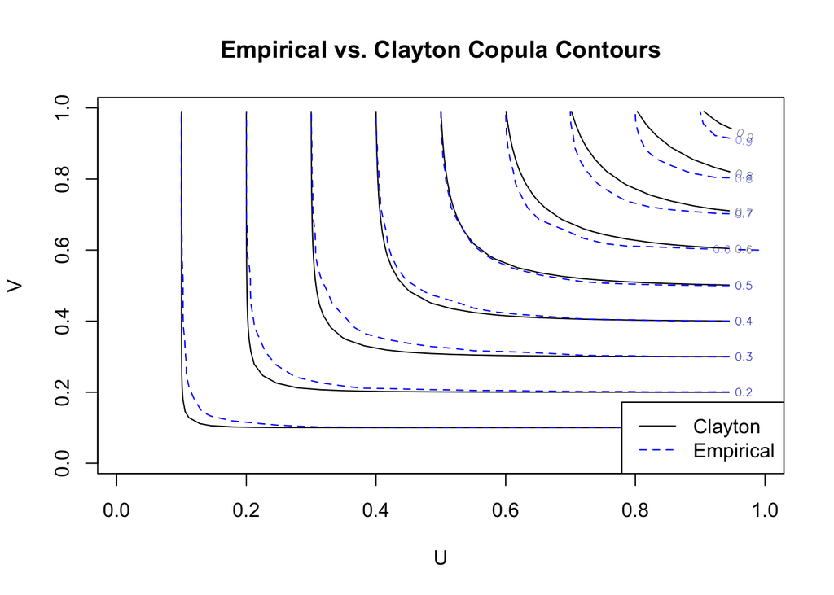

```r
emp_cop <- empCopula(u_data)
u <- v <- seq(0.01, 0.99, length.out = 30)
grid <- expand.grid(U = u, V = v)
emp_vals <- matrix(pCopula(as.matrix(grid), emp_cop), 30, 30)
clayton_est <- claytonCopula(param = fit.clayton@estimate)
clay_vals <- matrix(pCopula(as.matrix(grid), clayton_est), 30, 30)
contour(u, v, clay_vals,
        main = "Empirical vs. Clayton Copula Contours",
        xlab = "U", ylab = "V")
contour(u, v, emp_vals, add = TRUE, col = "blue", lty = 2)
legend("bottomright", legend = c("Clayton", "Empirical"),
       col = c("black", "blue"), lty = c(1, 2))
```

Question 2

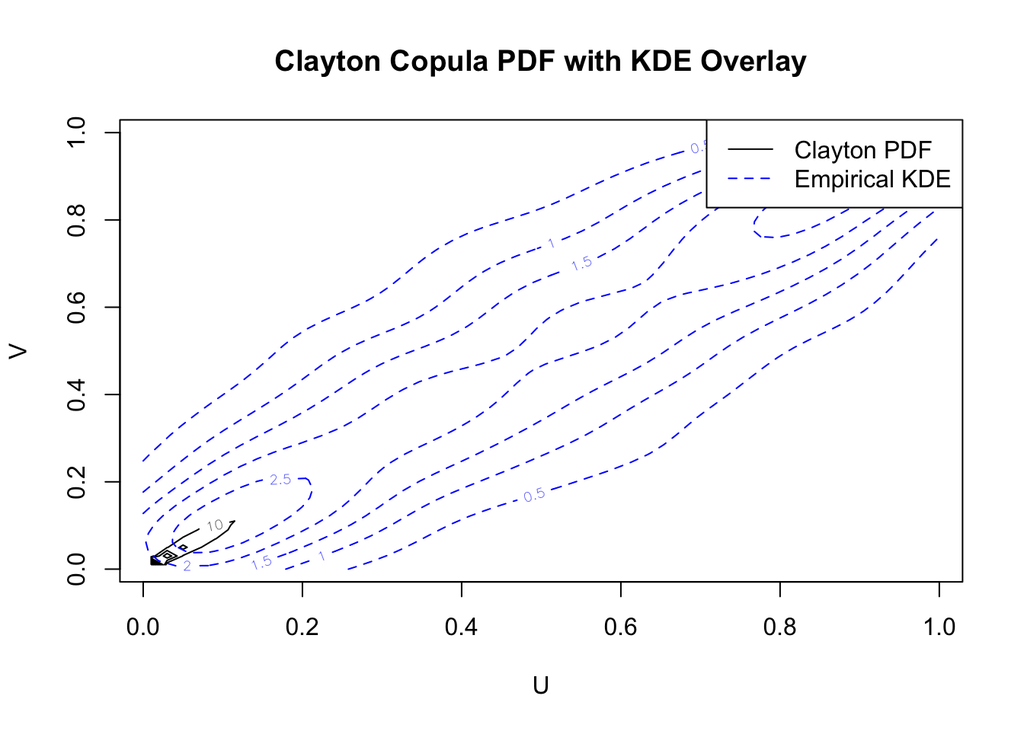

```r
u <- v <- seq(0.01, 0.99, length.out = 50)
grid <- expand.grid(U = u, V = v)
clayton_est <- claytonCopula(param = fit.clayton@estimate)
clayton_pdf <- matrix(dCopula(as.matrix(grid), clayton_est), nrow = 50)
contour(u, v, clayton_pdf,
        main = "Clayton Copula PDF with KDE Overlay",
        xlab = "U", ylab = "V")
kde_result <- kde2d(u_data[,1], u_data[,2], n = 50, lims = c(0,1,0,1))
contour(kde_result, add = TRUE, col = "blue", lty = 2)
legend("topright", legend = c("Clayton PDF", "Empirical KDE"),
       col = c("black", "blue"), lty = c(1, 2))
```

The plot compares the parametric density of the fitted Clayton copula, which are represented in the black lines with the non-parametric kernel density estimate represented in the blue dashed lines based on the BAC and JPM log returns. The Clayton copula shows the strongest connection between BAC and JPM when both are performing poorly. This is why the lines show the heavy dependence in the lower left corner. Meanwhile, the KDE is more flexible and show finer patterns in the data, especially in the middle and upper right parts. This shows that while the Clayton copula is good for some types of dependence like both stocks dropping, the KDE reveals more detailed patterns that the model might miss.

Question 3

```r
X <- logR[, "BAC.Adjusted"]
Y <- logR[, "JPM.Adjusted"]
var_X <- var(X)
var_Y <- var(Y)
cov_XY <- cov(X, Y)

alpha_hat <- (var_Y - cov_XY) / (var_X + var_Y - 2 * cov_XY)
alpha_hat
```

```
##              JPM.Adjusted
## JPM.Adjusted    0.0748293
```

```r
set.seed(123)
n <- nrow(logR)
B <- 1000
alpha_hats <- numeric(B)

for (i in 1:B) {
  idx <- sample(1:n, size = n, replace = TRUE)
  X_b <- X[idx]
  Y_b <- Y[idx]
  var_Xb <- var(X_b)
  var_Yb <- var(Y_b)
  cov_XYb <- cov(X_b, Y_b)
  alpha_hats[i] <- (var_Yb - cov_XYb) / (var_Xb + var_Yb - 2 * cov_XYb)
}
var_bootstrap <- var(alpha_hats)
var_bootstrap
```

```
## [1] 0.009677727
```

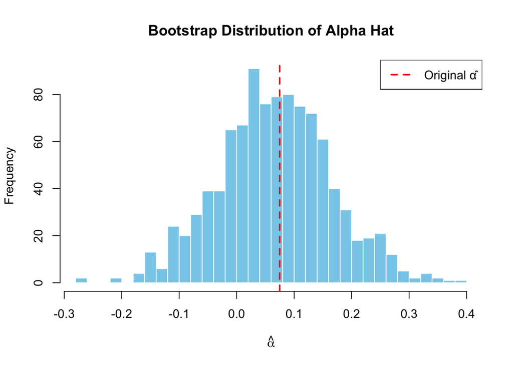

```r
hist(alpha_hats, breaks = 30, col = "skyblue",
     main = "Bootstrap Distribution of Alpha Hat",
     xlab = expression(hat(alpha)), border = "white")
abline(v = alpha_hat, col = "red", lwd = 2, lty = 2)
legend("topright", legend = c("Original α̂"), col = "red", lty = 2, lwd = 2)
```

Question 4a

```r
set.seed(123)
phi1 <- -0.5
phi2 <- 0.1
theta1 <- 0.3
n <- 50
burn_in <- 3

epsilon <- c(0, 0, 0, rnorm(n - burn_in))
Y <- numeric(n)
Y[1:3] <- 0
for (t in 4:n) {
  Y[t] <- phi1 * Y[t - 1] + phi2 * Y[t - 2] + epsilon[t] + theta1 * epsilon[t - 1]
}
Y
```

```
##  [1]  0.00000000  0.00000000  0.00000000 -0.56047565 -0.11808236  1.49264868
##  [7] -0.22001169  0.40971097  1.52699465  0.25290947 -1.10054164 -0.49080945
## [13] -0.51636726  1.29948589  0.02565869  0.62583484 -0.07943740 -0.42033414
## [19]  1.82238412  0.08069894 -1.67537307  0.95712719 -0.90848554 -0.65970564
## [25] -0.29931776 -1.00770861 -0.56277004 -0.66309248 -1.59893586  1.06493773
## [31] -0.28765322 -0.84180462  1.30451083  0.06617282 -0.06976754  0.84810527
## [37]  0.71564180  0.81201076  0.60067338  0.54137412 -0.10635613 -0.21722070
## [43] -0.37428506 -0.64342782 -0.13204397 -1.32609233  2.43917883  0.50645014
## [49] -0.77002717 -0.30415881
```

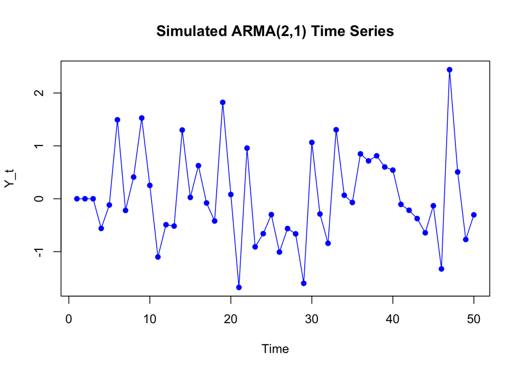

```r
plot(Y, type = "o", col = "blue", pch = 16,
     main = "Simulated ARMA(2,1) Time Series",
     ylab = "Y_t", xlab = "Time")
```

Question 4b

```r
set.seed(123)
phi <- c(-0.5, 0.1)
theta <- 0.3
n <- 50

innov <- c(0, 0, 0, rnorm(n - 3))
arma_sim <- arima.sim(model = list(ar = phi, ma = theta), n = n, innov = innov)
arma_sim
```

```
## Time Series:
## Start = 1
## End = 50
## Frequency = 1
##  [1]  0.03199124 -0.10672304  0.05656064 -0.59942827 -0.09294998  1.47618723
##  [7] -0.20926773  0.40269284  1.53157811  0.24991593 -1.09858653 -0.49208637
## [13] -0.51553329  1.29894122  0.02601443  0.62560251 -0.07928566 -0.42043324
## [19]  1.82244885  0.08065667 -1.67534546  0.95710915 -0.90847376 -0.65971333
## [25] -0.29931274 -1.00771189 -0.56276789 -0.66309388 -1.59893494  1.06493713
## [31] -0.28765283 -0.84180487  1.30451099  0.06617271 -0.06976747  0.84810522
## [37]  0.71564183  0.81201074  0.60067339  0.54137411 -0.10635613 -0.21722070
## [43] -0.37428506 -0.64342782 -0.13204397 -1.32609233  2.43917883  0.50645014
## [49] -0.77002717 -0.30415881
```

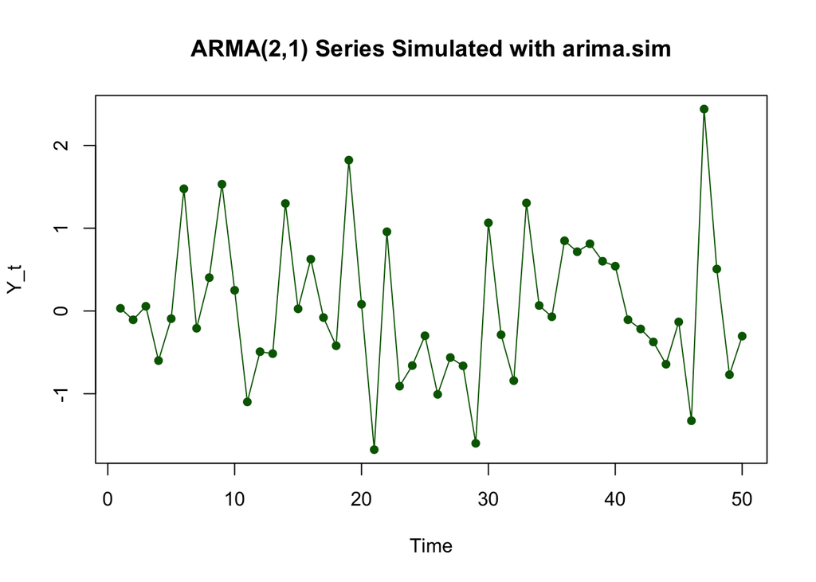

```r
plot(arma_sim, type = "o", col = "darkgreen", pch = 16,
     main = "ARMA(2,1) Series Simulated with arima.sim",
     ylab = "Y_t", xlab = "Time")
```

Question 4c

```r
phi <- c(-0.5, 0.1)
theta <- 0.3

theoretical_acf <- ARMAacf(ar = phi, ma = theta, lag.max = 20)
theoretical_acf
```

```
##             0             1             2             3             4
##  1.0000000000 -0.2540381791  0.2270190896 -0.1389133627  0.0921585903
##             5             6             7             8             9
## -0.0599706314  0.0392011747 -0.0255976505  0.0167189427 -0.0109192364
##            10            11            12            13            14
##  0.0071315125 -0.0046576799  0.0030419912 -0.0019867636  0.0012975809
##            15            16            17            18            19
## -0.0008474668  0.0005534915 -0.0003614924  0.0002360954 -0.0001541969
##            20
##  0.0001007080
```

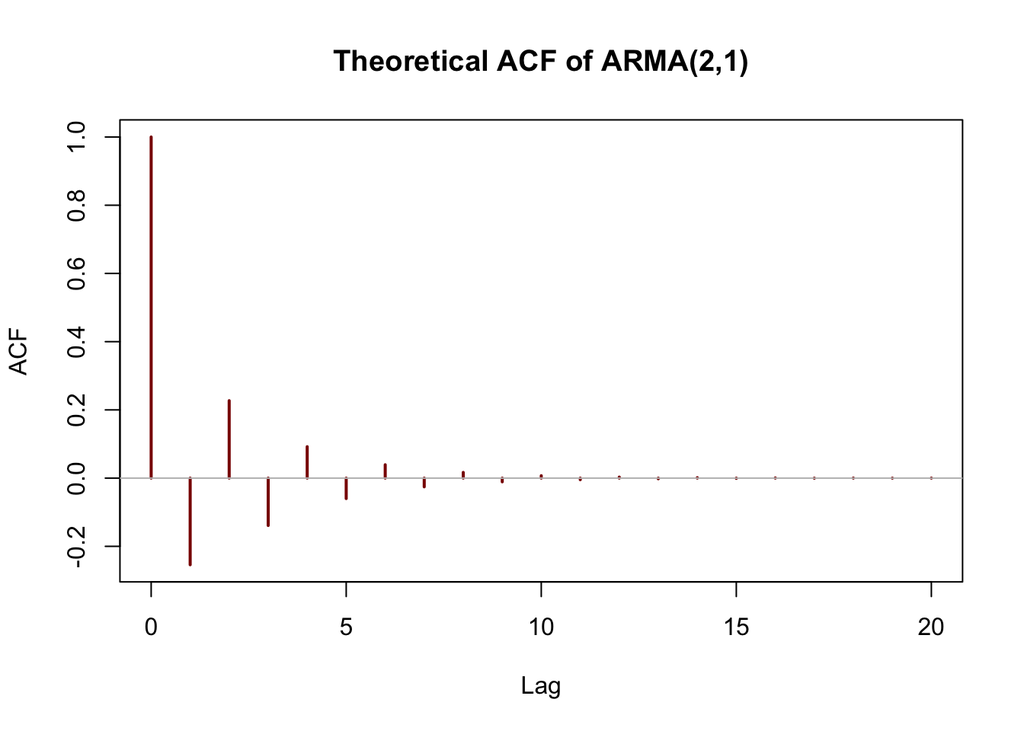

```r
plot(0:20, theoretical_acf, type = "h", lwd = 2, col = "darkred",
     main = "Theoretical ACF of ARMA(2,1)", xlab = "Lag", ylab = "ACF")
abline(h = 0, col = "gray")
```

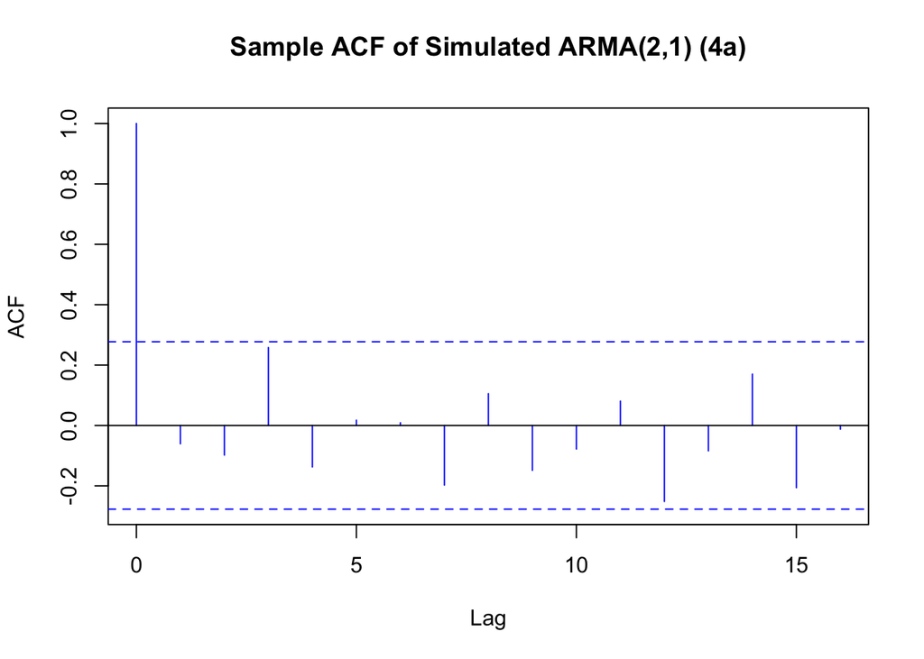

```r
acf(Y, main = "Sample ACF of Simulated ARMA(2,1) (4a)", col = "blue")
```

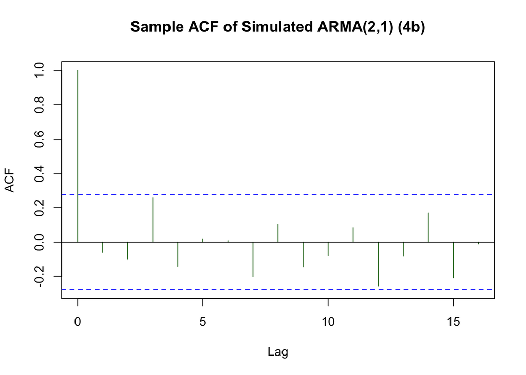

```r
acf(arma_sim, main = "Sample ACF of Simulated ARMA(2,1) (4b)", col = "darkgreen")
```

The results compare three different autocorrelation functions (ACFs), which are the theoretical ACF of an ARMA(2,1) process, and two sample ACFs based on simulated data from parts 4a and 4b. The theoretical ACF, which is shown in dark red, is calculated using the AR and MA coefficients directly and represents what the ACF should look like in an ideal, infinite sample setting. We see a clear declining pattern, which reflects the memory of the time series over increasing lags. This is a reference model that we compare the sample plots to in order to assess how well the simulation captures the underlying process.

Question 4d

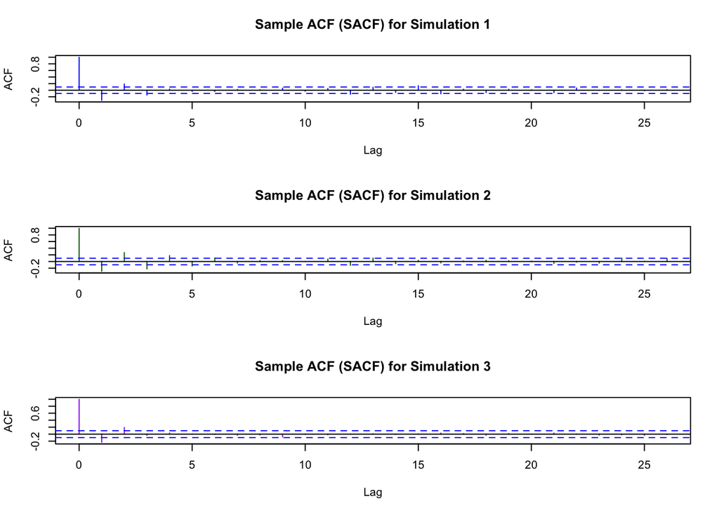

```r
phi <- c(-0.5, 0.1)
theta <- 0.3
n <- 400

sim1 <- arima.sim(model = list(ar = phi, ma = theta), n = n)
sim2 <- arima.sim(model = list(ar = phi, ma = theta), n = n)
sim3 <- arima.sim(model = list(ar = phi, ma = theta), n = n)

par(mfrow = c(3, 1))
acf(sim1, main = "Sample ACF (SACF) for Simulation 1", col = "blue")
acf(sim2, main = "Sample ACF (SACF) for Simulation 2", col = "darkgreen")
acf(sim3, main = "Sample ACF (SACF) for Simulation 3", col = "purple")
```

```r
par(mfrow = c(1, 1))
```

The three SACF plots for the simulated ARMA(2,1) processes all show similar general patterns, especially at lower lags. Each plot has a strong autocorrelation at lag 1 followed by smaller positive and negative autocorrelations that gradually decline, which is consistent with the expected behavior of an ARMA(2,1) process. This general shape reflects the impact of the AR and MA terms used in the model. Since we used the same model parameters for all three simulations, the structure of the SACFs remains quite similar.

However, due to the randomness in the white noise generated internally by arima.sim, we can observe slight differences in the SACFs beyond the first few lags. These differences are especially noticeable at higher lags, where the autocorrelation values fluctuate around zero more randomly. This variation is expected when working with simulated data and highlights the importance of using larger sample sizes or averaging multiple runs to better estimate the true autocorrelation structure. Overall, all three SACFs are consistent with an ARMA(2,1) model and only differ slightly due to random variation in the generated data.